# Parameter Recovery GCM

Jana Jarecki & Kilian Sennrich

22 7 2020

```r
#Libraries
pkgs <- c("data.table",
          "tidyverse",
          "Hmisc",
          "psych")

lapply(pkgs, library, character.only = TRUE)
```

```r
#Data // l = long; w = wide
data.l <- readRDS("../../data/raw/recovery_results.RDS")
data.l <- data.l[convergence != 1][, convergence := NULL]
data.w <- dcast(data = data.l,
                formula = run + discount + nblock + type + row ~ names,
                value.var = c("par", "true_par"))
```

There are 31 cases, where the GCM could not find optimal free parameters.

## 1. What interdependencies can be found between the variables?

In the following, I compile a correlation matrix to see, whether there are interdependencies between different variables. Significant correlation indicates some kind of systematic influence between the two variables involved. First, “row” and “run” columns are deleted from the data frame, that is because “run” is not expected to have significant influence and because all information of the “row” column if fully covered by the “true_par_lambda” and “true_par_tau” columns. Second, Spearman correlation is used to compile the correlation matrix. The nonparametric method is used, since not all the data is expected to meet criteria for pearson correlation. Third, correlation matrix is transformed to be in a more accessible format. Fourth, significant p-values are filtered. Knowing interdependencies gathers evidence for the decision to plot and test data either marginalized or conditioned.

```r
#Prepare data for correlation matrix
data.w.cor <- data.w[, -c("row", "run")]

#correlation matrix to check for interdependencies between the variables. Nonparametric method is used, since data did not meet criteria for pearson
cormat <- rcorr(as.matrix(data.w.cor), type = "spearman")
cormat.r <- as.data.frame(t(cormat$r))
cormat.p <- as.data.frame(cormat$P)
data.cor <-data.table(Var1 = rownames(cormat.r)[row(cormat.r)[upper.tri(cormat.r)]],
                      Var2 = colnames(cormat.r)[col(cormat.r)[upper.tri(cormat.r)]],
                      corr=round(cormat.r[upper.tri(cormat.r)],4),
                      p = round(cormat.p[upper.tri(cormat.p)],4))

#filter relevant values
data.cor.rel <- data.cor[corr != 0 & corr != 1 & corr != -1 & p < 0.05]
```

**Graphical analysis of the recovery of all parameters**

For every parameter, dependencies on other variables will be checked. Depending on this, the plots are designed as meaningful as possible. ### graph 1

```r
#recovery of b0
data.cor.rel[Var1 == "par_b0" | Var2 == "par_b0"]
```

```
##      Var1         Var2    corr      p
## 1:   type       par_b0  0.0240 0.0041
## 2: par_b0    par_color  0.0615 0.0000
## 3: par_b0     par_size -0.0427 0.0000
## 4: par_b0 true_par_tau -0.0282 0.0007
```

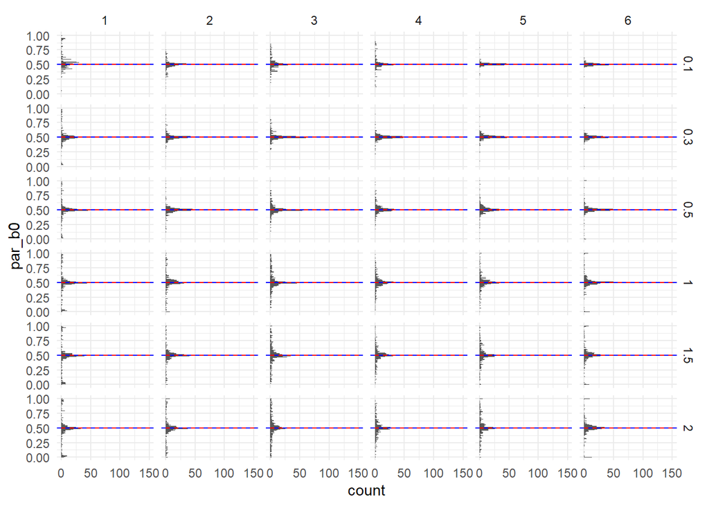

```r
data.w.b0 <- data.w %>%
  group_by(type, true_par_tau) %>%
  mutate(med_b0 = median(par_b0))

ggplot(data = data.w.b0,
       mapping = aes(y = par_b0)) +
  geom_histogram(bins = 100) +
  geom_hline(aes(yintercept = true_par_b0), color = "red") +
  geom_hline(aes(yintercept = med_b0), color="blue", linetype="dashed")+
  facet_grid(true_par_tau ~ type)+
  theme_minimal()
```

### graph 2

```r
#recovery of b1
data.cor.rel[Var1 == "par_b1" | Var2 == "par_b1"]
```

```
##      Var1         Var2    corr      p
## 1:   type       par_b1 -0.0240 0.0041
## 2: par_b1    par_color -0.0615 0.0000
## 3: par_b1     par_size  0.0427 0.0000
## 4: par_b1 true_par_tau  0.0282 0.0007
```

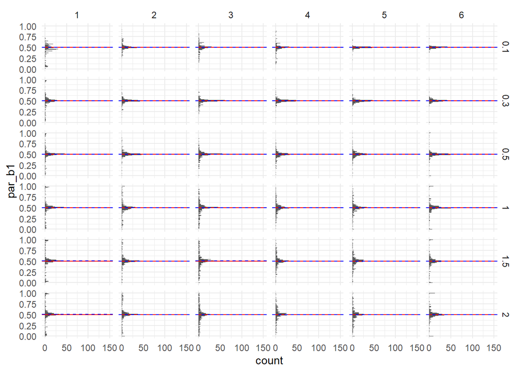

```r
data.w.b1 <- data.w %>%
  group_by(type, true_par_tau) %>%
  mutate(med_b1 = median(par_b1))

ggplot(data = data.w.b1,
       mapping = aes(y = par_b1)) +
  geom_histogram(bins = 100) +
  geom_hline(aes(yintercept = true_par_b1), color = "red") +
  geom_hline(aes(yintercept = med_b1), color="blue", linetype="dashed")+
  facet_grid(true_par_tau ~ type) +
  theme_minimal()
```

### graph 3

```r
#recovery of size
data.cor.rel[Var1 == "par_size" | Var2 == "par_size"]
```

```
##          Var1            Var2    corr p
## 1:       type        par_size  0.0980 0
## 2:     par_b0        par_size -0.0427 0
## 3:     par_b1        par_size  0.0427 0
## 4:  par_color        par_size -0.5058 0
## 5: par_lambda        par_size  0.1113 0
## 6:  par_shape        par_size -0.3669 0
## 7:   par_size         par_tau -0.1068 0
## 8:   par_size true_par_lambda  0.0409 0
## 9:   par_size    true_par_tau -0.0425 0
```

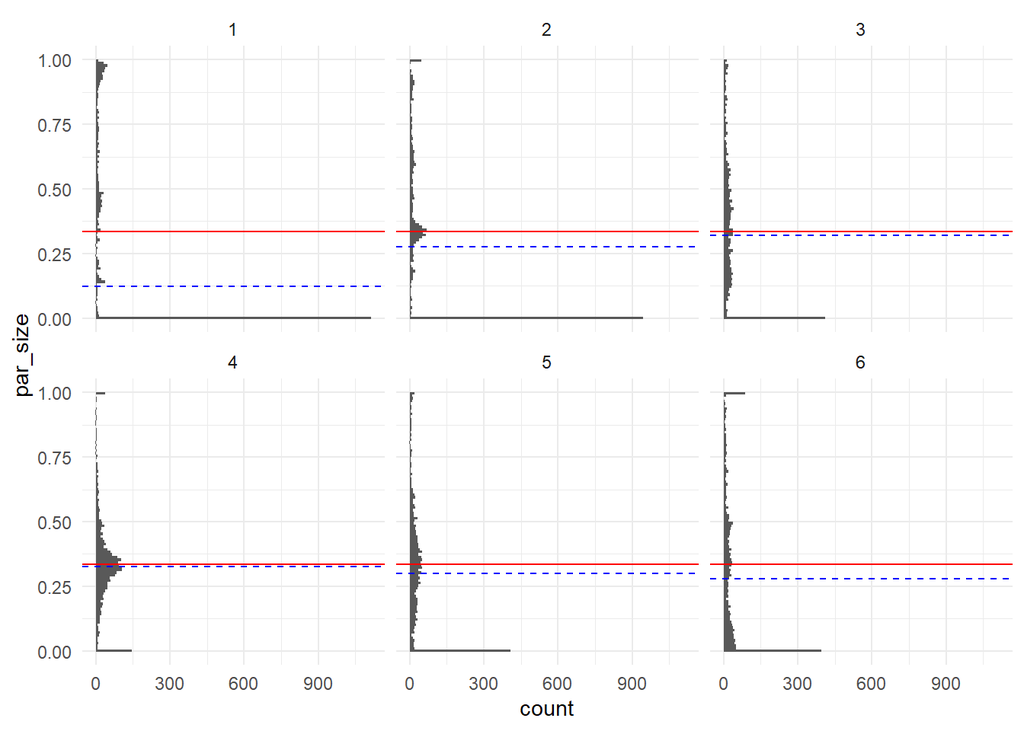

```r
data.w.size <- data.w %>%
  group_by(type) %>%
  mutate(med_size = median(par_size))

ggplot(data = data.w.size,
       mapping = aes(y = par_size)) +
  geom_histogram(bins = 100) +
  geom_hline(aes(yintercept = true_par_size), color = "red") +
  geom_hline(aes(yintercept = med_size, group = type), color="blue", linetype="dashed")+
  facet_wrap(~type)+
  theme_minimal()
```

###graph 4

```r
#recovery of color
data.cor.rel[Var1 == "par_color" | Var2 == "par_color"]
```

```
##         Var1            Var2    corr      p
## 1:    nblock       par_color  0.0204 0.0145
## 2:    par_b0       par_color  0.0615 0.0000
## 3:    par_b1       par_color -0.0615 0.0000
## 4: par_color      par_lambda -0.0884 0.0000
## 5: par_color       par_shape -0.4185 0.0000
## 6: par_color        par_size -0.5058 0.0000
## 7: par_color         par_tau  0.0907 0.0000
## 8: par_color true_par_lambda  0.0810 0.0000
## 9: par_color    true_par_tau -0.0437 0.0000
```

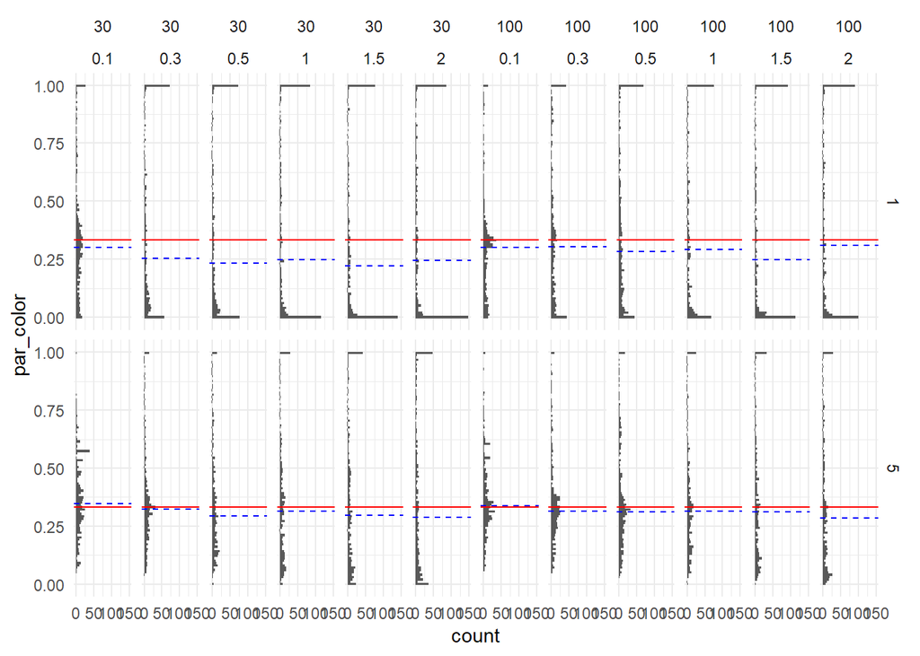

```r
data.w.color <- data.w %>%
  group_by(nblock, true_par_lambda, true_par_tau) %>%
  mutate(med_color = median(par_color))

ggplot(data = data.w.color,
       mapping = aes(y = par_color)) +
  geom_histogram(bins = 100) +
  geom_hline(aes(yintercept = true_par_color), color = "red") +
  geom_hline(aes(yintercept = med_color), color="blue", linetype="dashed")+
  facet_grid(true_par_lambda ~ nblock + true_par_tau) +
  theme_minimal()
```

### graph 5

```r
#recovery of shape
data.cor.rel[Var1 == "par_shape" | Var2 == "par_shape"]
```

```
##          Var1            Var2    corr     p
## 1:       type       par_shape  0.0814 0e+00
## 2:  par_color       par_shape -0.4185 0e+00
## 3: par_lambda       par_shape  0.0277 9e-04
## 4:  par_shape        par_size -0.3669 0e+00
## 5:  par_shape         par_tau -0.0439 0e+00
## 6:  par_shape true_par_lambda  0.0536 0e+00
## 7:  par_shape    true_par_tau -0.0609 0e+00
```

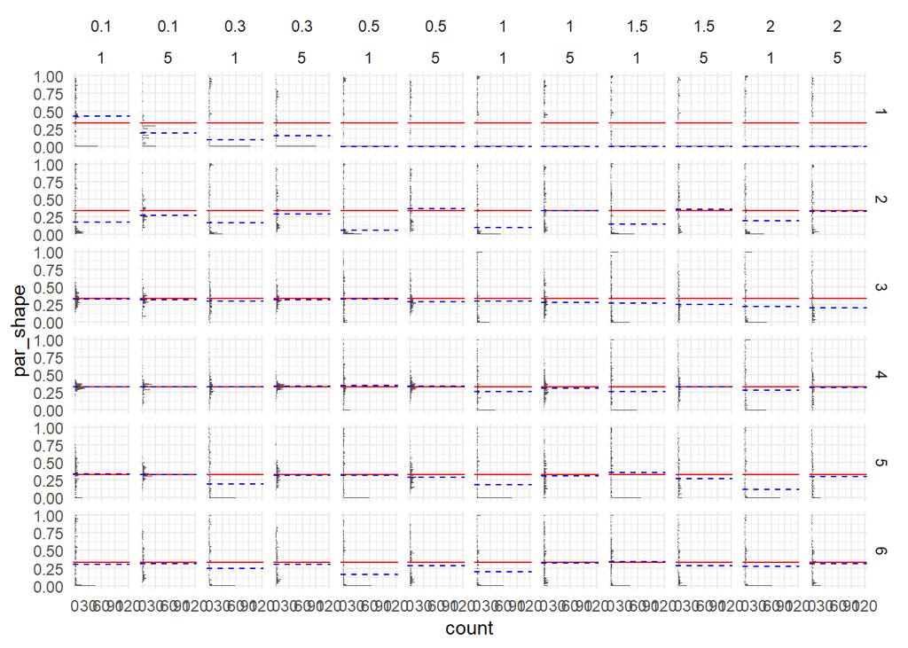

```r
data.w.shape <- data.w %>%
  group_by(true_par_tau, true_par_lambda, type) %>%
  mutate(med_shape = median(par_shape))

ggplot(data = data.w.shape,
       mapping = aes(y = par_shape)) +
  geom_histogram(bins = 100) +
  geom_hline(aes(yintercept = true_par_shape), color = "red") +
  geom_hline(aes(yintercept = med_shape), color="blue", linetype="dashed") +
  facet_grid(type ~ true_par_tau + true_par_lambda) +
  theme_minimal()
```

### graph 6

```r
#recovery of lambda
data.cor.rel[Var1 == "par_lambda" | Var2 == "par_lambda"]
```

```
##          Var1            Var2    corr      p
## 1:       type      par_lambda -0.0448 0.0000
## 2:  par_color      par_lambda -0.0884 0.0000
## 3: par_lambda       par_shape  0.0277 0.0009
## 4: par_lambda        par_size  0.1113 0.0000
## 5: par_lambda         par_tau  0.3029 0.0000
## 6: par_lambda true_par_lambda  0.4023 0.0000
## 7: par_lambda    true_par_tau  0.0244 0.0034
```

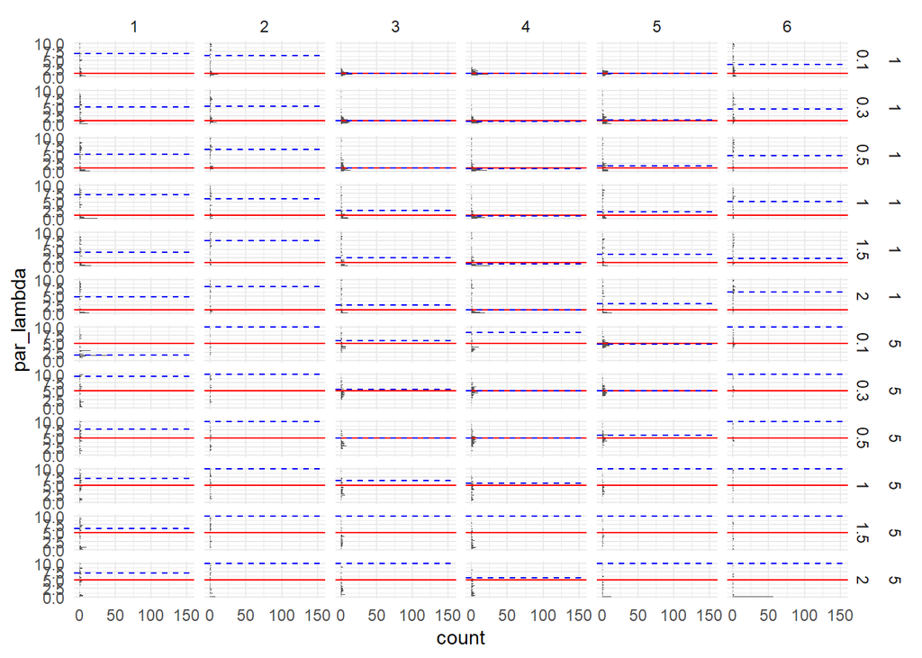

```r
data.w.lambda <- data.w %>%
  group_by(true_par_lambda, true_par_tau, type) %>%
  mutate(med_lambda = median(par_lambda))

ggplot(data = data.w.lambda,
       mapping = aes(y = par_lambda)) +
  geom_histogram(bins = 100) +
  geom_hline(aes(yintercept = true_par_lambda), color = "red") +
  geom_hline(aes(yintercept = med_lambda), color="blue", linetype="dashed")+
  facet_grid(true_par_lambda + true_par_tau ~ type)+
  theme_minimal()
```

#graph 7

```r
#recovery of tau
data.cor.rel[Var1 == "par_tau" | Var2 == "par_tau"]
```

```
##          Var1         Var2    corr     p
## 1:     nblock      par_tau  0.0316 2e-04
## 2:  par_color      par_tau  0.0907 0e+00
## 3: par_lambda      par_tau  0.3029 0e+00
## 4:  par_shape      par_tau -0.0439 0e+00
## 5:   par_size      par_tau -0.1068 0e+00
## 6:    par_tau true_par_tau  0.6554 0e+00
```

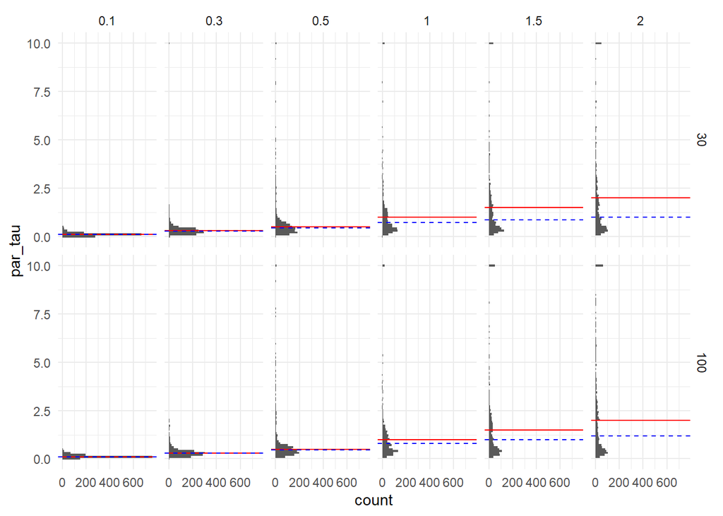

```r
data.w.tau <- data.w %>%
  group_by(true_par_tau, nblock) %>%
  mutate(med_tau = median(par_tau))

ggplot(data = data.w.tau,
       mapping = aes(y = par_tau)) +
  geom_histogram(bins = 100) +
  geom_hline(aes(yintercept = true_par_tau), color = "red") +
  geom_hline(aes(yintercept = med_tau), color="blue", linetype="dashed")+
  facet_grid(nblock ~ true_par_tau) +
  theme_minimal()
```

```r
#subset data for further testing
cormat.test <- data.table(data.w[, c("par_tau", "true_par_tau" , "discount", "nblock", "type", "true_par_lambda")])
```

## 2. Impact of omitting the first 3 and 8 rows on recovering tau

According to the GCM, omitting the first 3 or 8 rows should lead to better recovery of the tau parameter. Reason being, that the machine learning algorithm does not make accurate decisions on early rows of training. To further test the effect of omitting the aforementioned rows, spearman correlation coefficients will be compared in a correlation test. Since nblock seems to have impact on par_tau (although correlation is small and could have emerged due to randomness), separate testing for nblock = 30 and nblock = 100 is advised.

```r
# decision between marginalized vs. conditionized testing
data.cor.rel[Var1 == "par_tau" | Var2 == "par_tau"] #influence on tau
```

```
##          Var1         Var2    corr     p
## 1:     nblock      par_tau  0.0316 2e-04
## 2:  par_color      par_tau  0.0907 0e+00
## 3: par_lambda      par_tau  0.3029 0e+00
## 4:  par_shape      par_tau -0.0439 0e+00
## 5:   par_size      par_tau -0.1068 0e+00
## 6:    par_tau true_par_tau  0.6554 0e+00
```

```r
data.cor.rel[Var1 == "discount" | Var2 == "discount"]#influence on discount
```

```
## Empty data.table (0 rows and 4 cols): Var1,Var2,corr,p
```

```r
data.cor.rel[Var1 == "true_par_tau" | Var2 == "true_par_tau"] #influence on true tau
```

```
##          Var1         Var2    corr      p
## 1:     par_b0 true_par_tau -0.0282 0.0007
## 2:     par_b1 true_par_tau  0.0282 0.0007
## 3:  par_color true_par_tau -0.0437 0.0000
## 4: par_lambda true_par_tau  0.0244 0.0034
## 5:  par_shape true_par_tau -0.0609 0.0000
## 6:   par_size true_par_tau -0.0425 0.0000
## 7:    par_tau true_par_tau  0.6554 0.0000
```

```r
#subset discounts
cormat.test.d0n30 <- cormat.test[discount == 0 & nblock == 30]
cormat.test.d8n30 <- cormat.test[discount == 8 & nblock == 30]
cormat.test.d0n100 <- cormat.test[discount == 0 & nblock == 100]
cormat.test.d8n100 <- cormat.test[discount == 8 & nblock == 100]
```

```r
#correlation test for nblock = 30
r.test(n = nrow(cormat.test.d0n30),
       n2 = nrow(cormat.test.d8n30),
       r12 = cor(cormat.test.d0n30$par_tau,
                 cormat.test.d0n30$true_par_tau,
                 method = "spearman"),
       r34 = cor(cormat.test.d8n30$par_tau,
                 cormat.test.d8n30$true_par_tau,
                 method = "spearman"))
```

```
## Correlation tests
## Call:r.test(n = nrow(cormat.test.d0n30), r12 = cor(cormat.test.d0n30$par_tau,
##     cormat.test.d0n30$true_par_tau, method = "spearman"), r34 = cor(cormat.test.d8n30$par_tau,
##     cormat.test.d8n30$true_par_tau, method = "spearman"), n2 = nrow(cormat.test.d8n30))
## Test of difference between two independent correlations
##  z value 0.97    with probability  0.33
```

```r
#correlation test for nblock = 100
r.test(n = nrow(cormat.test.d0n100),
       n2 = nrow(cormat.test.d8n100),
       r12 = cor(cormat.test.d0n100$par_tau,
                 cormat.test.d0n100$true_par_tau,
                 method = "spearman"),
       r34 = cor(cormat.test.d8n100$par_tau,
                 cormat.test.d8n100$true_par_tau,
                 method = "spearman"))
```

```
## Correlation tests
## Call:r.test(n = nrow(cormat.test.d0n100), r12 = cor(cormat.test.d0n100$par_tau,
##     cormat.test.d0n100$true_par_tau, method = "spearman"), r34 = cor(cormat.test.d8n100$par_tau,
##     cormat.test.d8n100$true_par_tau, method = "spearman"), n2 = nrow(cormat.test.d8n100))
## Test of difference between two independent correlations
##  z value 0.75    with probability  0.45
```

**Graphical evaluation** ### graph 8

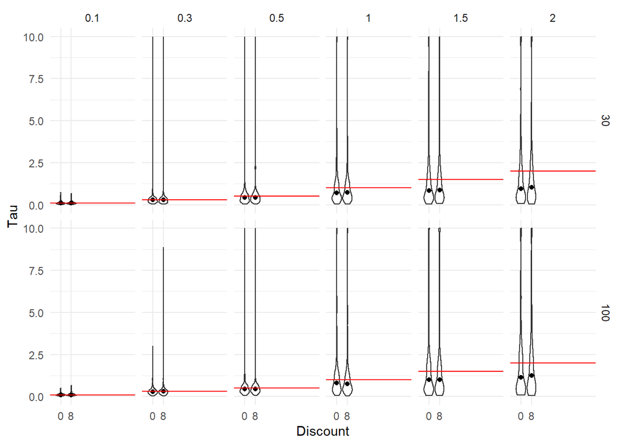

```r
#violin plots for discount per par_tau (Ev müssen wir noch konditionieren)
ggplot(data = data.w,
       mapping = aes(x = as.factor(discount),
                     y = par_tau)) +
  geom_violin(width = 0.9) +
  stat_summary(fun = "median",
               geom = "point") +
  geom_line(aes(x = discount,
                y = true_par_tau),
            color = "red",
            size = 0.5) +
  facet_grid(nblock ~ true_par_tau)+
  ylim(0, 10) +
  xlab("Discount") +
  ylab("Tau") +
  theme_minimal()
```

### graph 9

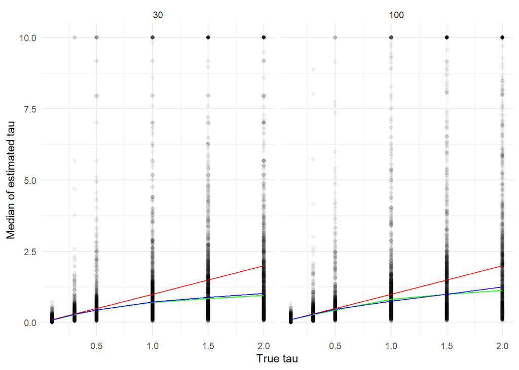

```r
# line plot
ggplot(data = data.w,
       mapping = aes(x = true_par_tau,
                     y = par_tau)) +
  geom_point(aes(x = true_par_tau,
                 y = par_tau),
             alpha = 1 / 20) +
  geom_line(aes(x = true_par_tau,
                y = true_par_tau),
            color = "red") +
  stat_summary(aes(group = discount),
               fun = median,
               geom = "line",
               color = c(rep("green", 6), #discount = 0
                         rep("blue", 6),  #discount = 8
                         rep("green", 6), #discount = 0
                         rep("blue", 6)   #discount = 8
                         ))+
  facet_wrap(~nblock) +
  ylim(0,10) +
  xlab("True tau") +
  ylab("Median of estimated tau") +
  theme_minimal()
```

## 3. Impact of training with multiple blocks on recovery of tau

```r
# decision between marginalized vs. conditionized testing
data.cor.rel[Var1 == "nblock" | Var2 == "nblock"]#influence on nblock
```

```
##      Var1      Var2   corr      p
## 1: nblock par_color 0.0204 0.0145
## 2: nblock   par_tau 0.0316 0.0002
```

```r
#subset nblock
cormat.test.n30 <- cormat.test[nblock == 30]
cormat.test.n100 <- cormat.test[nblock == 100]
```

```r
#correlation test
r.test(n = nrow(cormat.test.n30),
       n2 = nrow(cormat.test.n100),
       r12 = cor(cormat.test.n30$par_tau,
                 cormat.test.n30$true_par_tau,
                 method = "spearman"),
       r34 = cor(cormat.test.n100$par_tau,
                 cormat.test.n100$true_par_tau,
                 method = "spearman"))
```

```
## Correlation tests
## Call:r.test(n = nrow(cormat.test.n30), r12 = cor(cormat.test.n30$par_tau,
##     cormat.test.n30$true_par_tau, method = "spearman"), r34 = cor(cormat.test.n100$par_tau,
##     cormat.test.n100$true_par_tau, method = "spearman"), n2 = nrow(cormat.test.n100))
## Test of difference between two independent correlations
##  z value 1.19    with probability  0.23
```

**Graphical analysis** ### graph 10

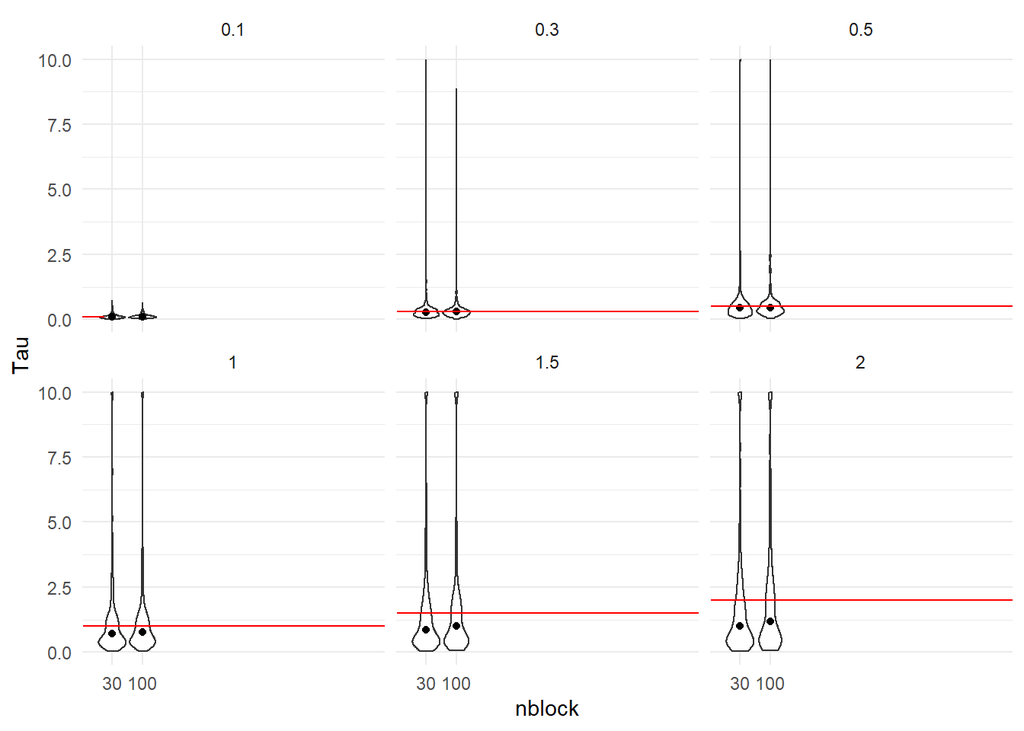

```r
#violin plots for nblock per par_tau
ggplot(data = data.w,
       mapping = aes(x = as.factor(nblock),
                     y = par_tau)) +
  geom_violin(width = 0.9) +
  stat_summary(fun = "median",
               geom = "point") +
  geom_line(aes(x = par_tau,
                y = true_par_tau),
            color = "red",
            size = 0.5) +
  facet_wrap(~true_par_tau)+
  ylim(0, 10) +
  xlab("nblock") +
  ylab("Tau") +
  theme_minimal()
```

### graph 11

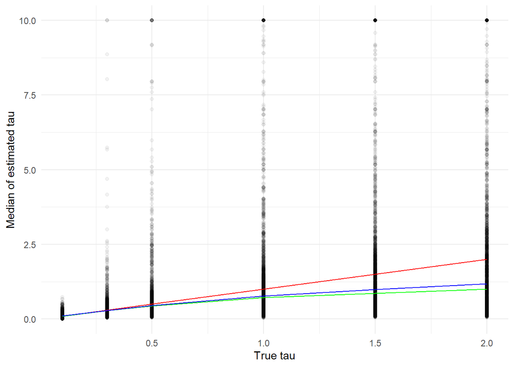

```r
# line plot
ggplot(data = data.w,
       mapping = aes(x = true_par_tau,
                     y = par_tau)) +
  geom_point(aes(x = true_par_tau,
                 y = par_tau),
             alpha = 1 / 20) +
  geom_line(aes(x = true_par_tau,
                y = true_par_tau),
            color = "red") +
  stat_summary(aes(group = nblock),
               fun = median,
               geom = "line",
               color = c(rep("green", 6),  #nblock = 30
                         rep("blue", 6)    #nblock = 100
                         ))+
  ylim(0,10) +
  xlab("True tau") +
  ylab("Median of estimated tau") +
  theme_minimal()
```

## 4. ability of the GCM to grasp the difficulty of the categories on the tau parameter

```r
# decision between marginalized vs. conditionized testing
data.cor.rel[Var1 == "type" | Var2 == "type"]#influence on type
```

```
##    Var1       Var2    corr      p
## 1: type     par_b0  0.0240 0.0041
## 2: type     par_b1 -0.0240 0.0041
## 3: type par_lambda -0.0448 0.0000
## 4: type  par_shape  0.0814 0.0000
## 5: type   par_size  0.0980 0.0000
```

```r
#subset types
cormat.test.30.1 <- cormat.test[nblock == 30 & type == 1]
cormat.test.30.2 <- cormat.test[nblock == 30 & type == 2]
cormat.test.30.3 <- cormat.test[nblock == 30 & type == 3]
cormat.test.30.4 <- cormat.test[nblock == 30 & type == 4]
cormat.test.30.5 <- cormat.test[nblock == 30 & type == 5]
cormat.test.30.6 <- cormat.test[nblock == 30 & type == 6]

cormat.test.100.1 <- cormat.test[nblock == 100 & type == 1]
cormat.test.100.2 <- cormat.test[nblock == 100 & type == 2]
cormat.test.100.3 <- cormat.test[nblock == 100 & type == 3]
cormat.test.100.4 <- cormat.test[nblock == 100 & type == 4]
cormat.test.100.5 <- cormat.test[nblock == 100 & type == 5]
cormat.test.100.6 <- cormat.test[nblock == 100 & type == 6]
```

```r
#calculate correlation test for all expressions of type
rtest.results <- list()
cormat.res <- list()


l = 1

for (i in 1:6) {
  for (j in 1:6) {
    for (k in c(30, 100)){
      for (m in c(30, 100)) {

    #select components to apply r.test
    component1 <- get(paste("cormat.test", k, i, sep = "."))
    component2 <- get(paste("cormat.test", m, j, sep = "."))

    #calculate r.test and save it to rtest.results
    rtest.results[[l]] <- r.test(n = nrow(component1),
                                 n2 = nrow(component2),
                                 r12 = cor(component1$par_tau,
                                           component1$true_par_tau,
                                           method = "spearman"),
                                 r34 = cor(component2$par_tau,
                                           component2$true_par_tau,
                                           method = "spearman"))

    #draw compatible list to later convert to data.table
    cormat.res[[l]] <-  data.table(
        component1 = paste0("type=", i),
        component2 = paste0("type=", j),
        nblock_comp1 = k,
        nblock_comp2 = m,
        p_value = round(rtest.results[[l]]$p, 4),
        z_score = round(rtest.results[[l]]$z, 4)
    )

      l = l + 1
      }
    }
  }
}

cormat.res <- rbindlist(cormat.res)
cormat.res <- cormat.res[z_score != 0]

cormat.res.rel <- cormat.res[p_value < 0.05]

print(cormat.res.rel)
```

```
##     component1 component2 nblock_comp1 nblock_comp2 p_value z_score
##  1:     type=1     type=3           30           30  0.0000  5.3011
##  2:     type=1     type=3           30          100  0.0000  5.6909
##  3:     type=1     type=3          100           30  0.0000  5.4430
##  4:     type=1     type=3          100          100  0.0000  5.8322
##  5:     type=1     type=4           30           30  0.0006  3.4338
##  6:     type=1     type=4           30          100  0.0000  4.8122
##  7:     type=1     type=4          100           30  0.0003  3.5789
##  8:     type=1     type=4          100          100  0.0000  4.9550
##  9:     type=1     type=5           30           30  0.0003  3.6197
## 10:     type=1     type=5           30          100  0.0000  4.1982
## 11:     type=1     type=5          100           30  0.0002  3.7645
## 12:     type=1     type=5          100          100  0.0000  4.3420
## 13:     type=2     type=3           30           30  0.0001  3.9738
## 14:     type=2     type=3           30          100  0.0000  4.3634
```

[output cut: 63 more lines]

**Graphical analysis** ### graph 12

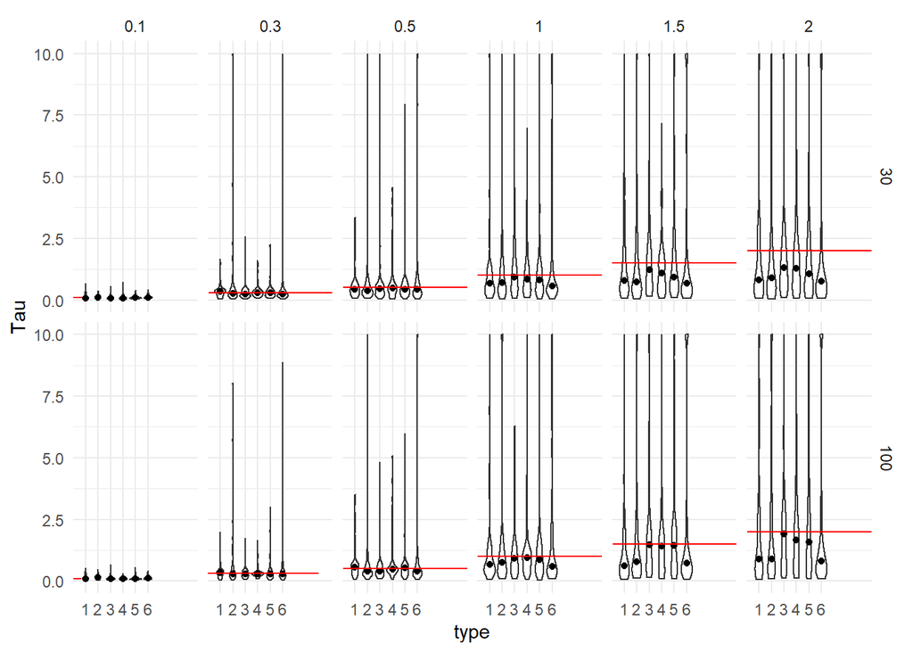

```r
#violin plots for par_tau per type
ggplot(data = data.w,
       mapping = aes(x = as.factor(type),
                     y = par_tau)) +
  geom_violin(width = 0.9) +
  stat_summary(fun = "median",
               geom = "point") +
  geom_line(aes(x = par_tau,
                y = true_par_tau),
            color = "red",
            size = 0.5) +
  facet_grid(nblock ~ true_par_tau)+
  ylim(0, 10) +
  xlab("type") +
  ylab("Tau") +
  theme_minimal()
```

#graph 13

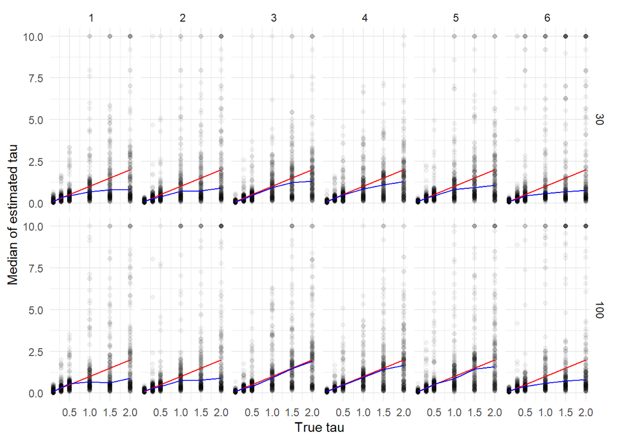

```r
# line plot
ggplot(data = data.w,
       mapping = aes(x = true_par_tau,
                     y = par_tau)) +
  geom_point(aes(x = true_par_tau,
                 y = par_tau),
             alpha = 1 / 20) +
  geom_line(aes(x = true_par_tau,
                y = true_par_tau),
            color = "red") +
  stat_summary(aes(group = type),
               fun = median,
               geom = "line",
               color = c(rep("blue", 72)
                         ))+
  facet_grid(nblock ~ type)+
  ylim(0,10) +
  xlab("True tau") +
  ylab("Median of estimated tau") +
  theme_minimal()
```

## 5. Influence of Lambda on the recovery of Tau

```r
# decision between marginalized vs. conditionized testing
data.cor.rel[Var1 == "true_par_lambda" | Var2 == "true_par_lambda"]#influence on discount
```

```
##          Var1            Var2   corr p
## 1:  par_color true_par_lambda 0.0810 0
## 2: par_lambda true_par_lambda 0.4023 0
## 3:  par_shape true_par_lambda 0.0536 0
## 4:   par_size true_par_lambda 0.0409 0
```

```r
#subset discounts
cormat.test.lam1.30 <- cormat.test[nblock == 30 & true_par_lambda == 1]
cormat.test.lam5.30 <- cormat.test[nblock == 30 & true_par_lambda == 5]
cormat.test.lam1.100 <- cormat.test[nblock == 100 & true_par_lambda == 1]
cormat.test.lam5.100 <- cormat.test[nblock == 100 & true_par_lambda == 5]
```

```r
#correlation test
r.test(n = nrow(cormat.test.lam1.30),
       n2 = nrow(cormat.test.lam5.30),
       r12 = cor(cormat.test.lam1.30$par_tau,
                 cormat.test.lam1.30$true_par_tau,
                 method = "spearman"),
       r34 = cor(cormat.test.lam5.30$par_tau,
                 cormat.test.lam5.30$true_par_tau,
                 method = "spearman"))
```

```
## Correlation tests
## Call:r.test(n = nrow(cormat.test.lam1.30), r12 = cor(cormat.test.lam1.30$par_tau,
##     cormat.test.lam1.30$true_par_tau, method = "spearman"), r34 = cor(cormat.test.lam5.30$par_tau,
##     cormat.test.lam5.30$true_par_tau, method = "spearman"), n2 = nrow(cormat.test.lam5.30))
## Test of difference between two independent correlations
##  z value 8.72    with probability  0
```

```r
r.test(n = nrow(cormat.test.lam1.100),
       n2 = nrow(cormat.test.lam5.100),
       r12 = cor(cormat.test.lam1.100$par_tau,
                 cormat.test.lam1.100$true_par_tau,
                 method = "spearman"),
       r34 = cor(cormat.test.lam5.100$par_tau,
                 cormat.test.lam5.100$true_par_tau,
                 method = "spearman"))
```

```
## Correlation tests
## Call:r.test(n = nrow(cormat.test.lam1.100), r12 = cor(cormat.test.lam1.100$par_tau,
##     cormat.test.lam1.100$true_par_tau, method = "spearman"),
##     r34 = cor(cormat.test.lam5.100$par_tau, cormat.test.lam5.100$true_par_tau,
##         method = "spearman"), n2 = nrow(cormat.test.lam5.100))
## Test of difference between two independent correlations
##  z value 11.33    with probability  0
```

**Graphical analysis** ### graph 14

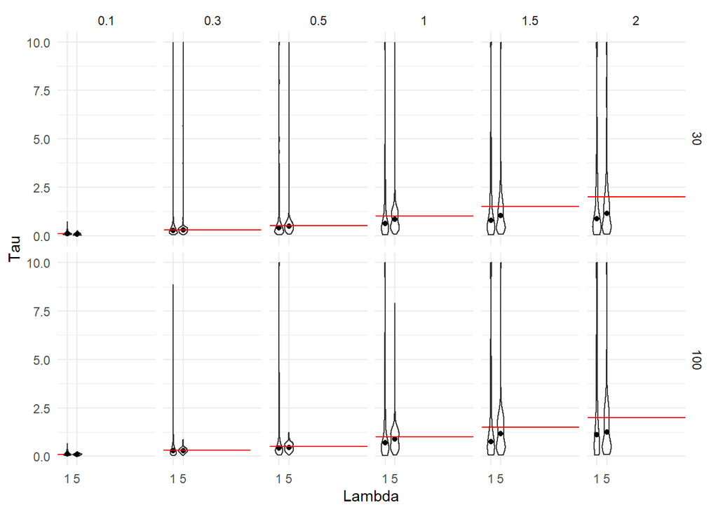

```r
#violin plots for true lambda per par_tau
ggplot(data = data.w,
       mapping = aes(x = as.factor(true_par_lambda),
                     y = par_tau)) +
  geom_violin(width = 0.9) +
  stat_summary(fun = "median",
               geom = "point") +
  geom_line(aes(x = par_tau,
                y = true_par_tau),
            color = "red",
            size = 0.5) +
  facet_grid(nblock ~ true_par_tau)+
  ylim(0, 10) +
  xlab("Lambda") +
  ylab("Tau") +
  theme_minimal()
```

###graph 15

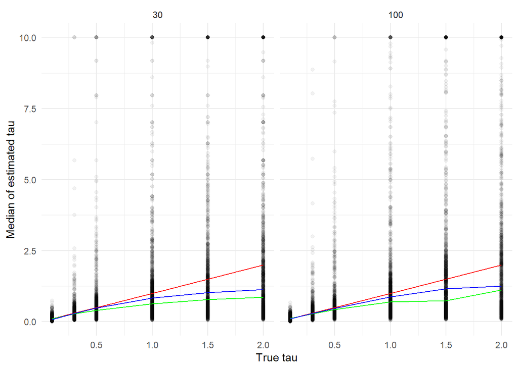

```r
# line plot
ggplot(data = data.w,
       mapping = aes(x = true_par_tau,
                     y = par_tau)) +
  geom_point(aes(x = true_par_tau,
                 y = par_tau),
             alpha = 1 / 20) +
  geom_line(aes(x = true_par_tau,
                y = true_par_tau),
            color = "red") +
  stat_summary(aes(group = true_par_lambda),
               fun = median,
               geom = "line",
               color = c(rep("green", 6),  #lambda = 1
                         rep("blue", 6),   #lambda = 5
                         rep("green", 6),  #lambda = 1
                         rep("blue", 6)    #lambda = 5
                         ))+
  facet_wrap(~nblock)+
  ylim(0,10) +
  xlab("True tau") +
  ylab("Median of estimated tau") +
  theme_minimal()
```